# TP4

2023-04-17

### TP4

Paul GAUTHIER, Célien BONHOMME, Alexandre GOURNAIL

## Part 1

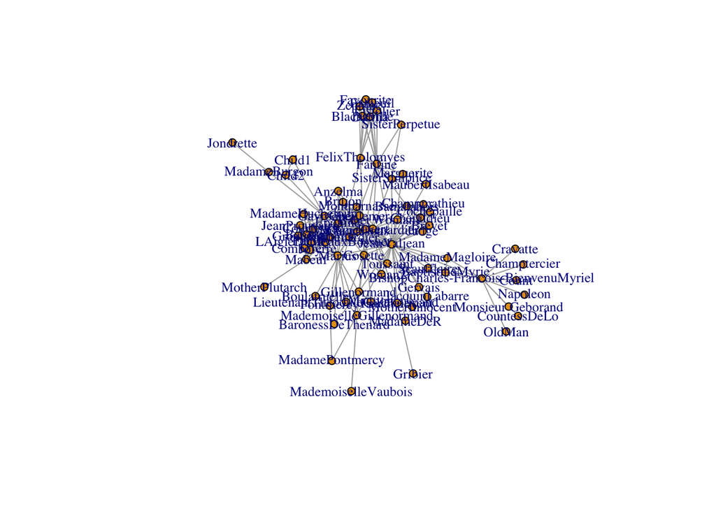

```r
dat <- read.table("lesmis.txt", header = FALSE, sep = "\t")
misgraph <- simplify(graph.data.frame(dat, directed=FALSE))

plot.igraph(misgraph, vertex.label.cex = 0.8, vertex.size = 5)
```

We can observe that without choosing a layout, the vizualisation of the graph is quite complicated due to the number of characters in the book (many nodes in the graph). That’s why we can use different choices of layout to represent different ways to position the vertices of the graph. Let’s try some layouts.

With the “Fruchterman-Reingold” layout :

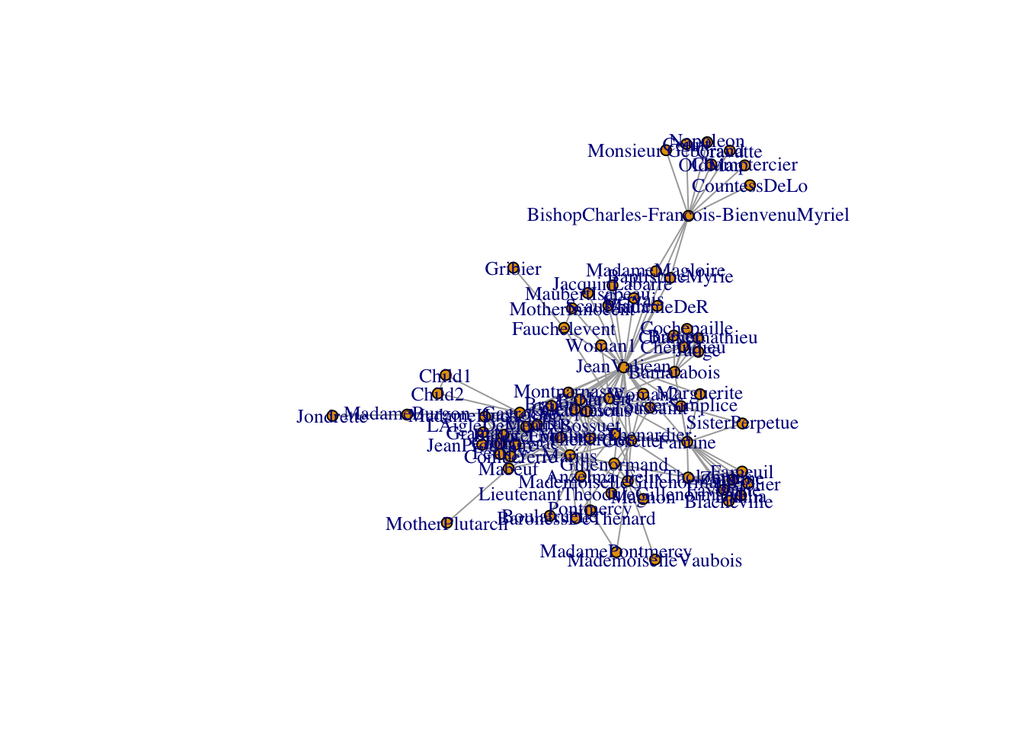

```r
l <- layout_with_fr(misgraph)
plot.igraph(misgraph, vertex.label.cex = 0.8, vertex.size = 5, layout=l)
```

With the “kk” layout :

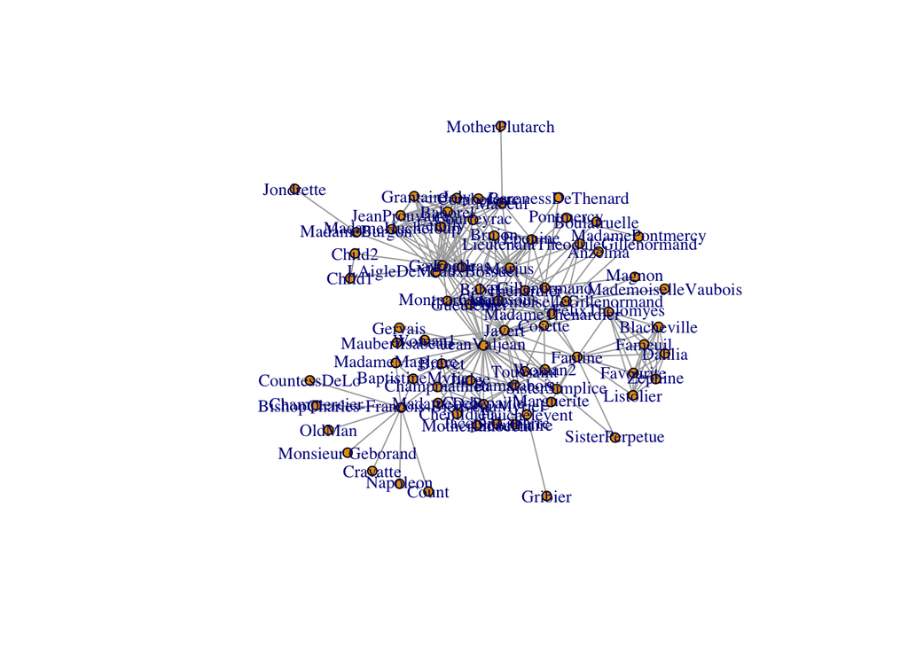

```r
l <- layout_with_kk(misgraph)
plot.igraph(misgraph, vertex.label.cex = 0.8, vertex.size = 5, layout=l)
```

With the “Davidson-Harel” layout :

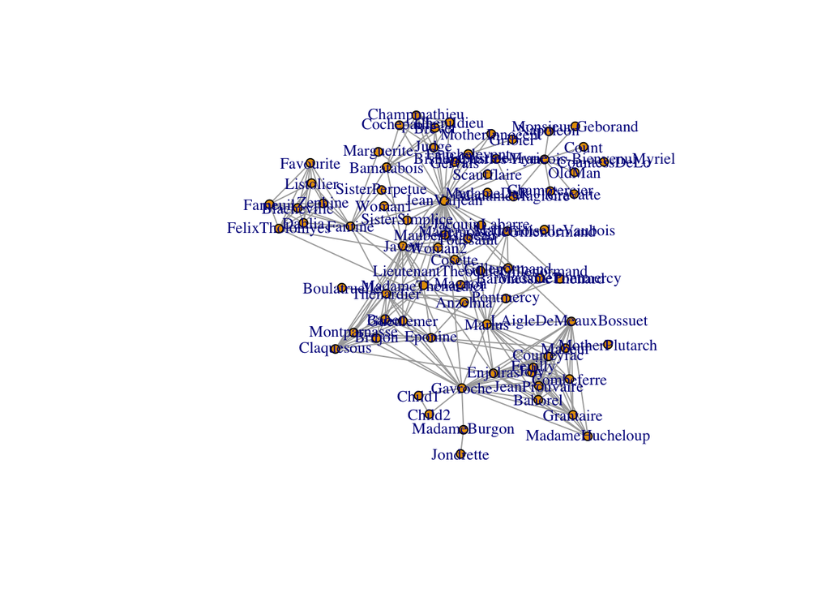

```r
l <- layout_with_dh(misgraph)
plot.igraph(misgraph, vertex.label.cex = 0.8, vertex.size = 5, layout=l)
```

2. The graph is an undirected graph.

```
## [1] 77
```

```
## [1] 254
```

The density of the graph is :

```
## [1] 0.08680793
```

The diameter of the graph is :

```
## [1] 5
```

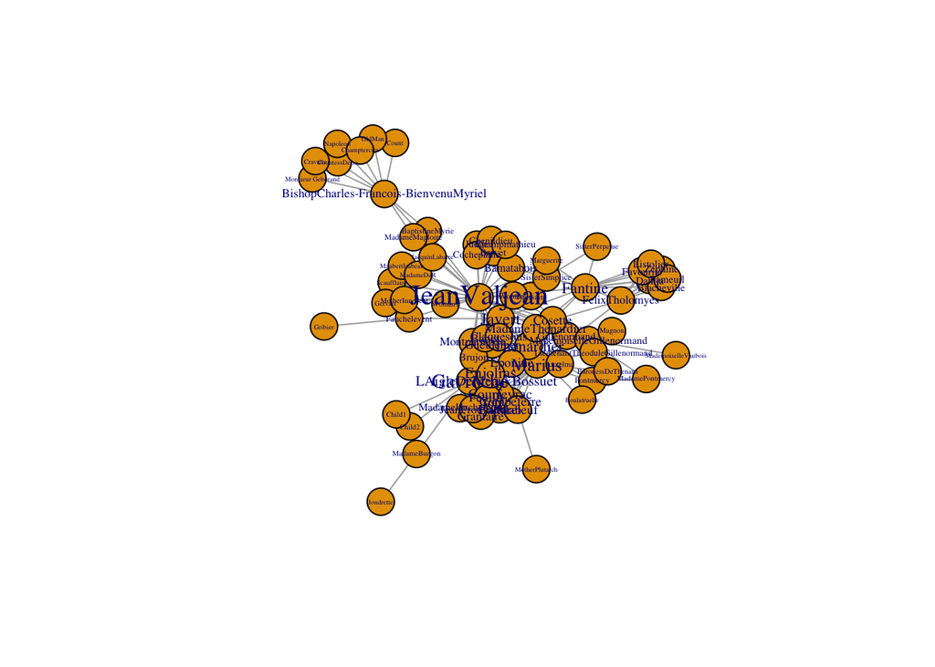

```r
set.seed(3)
V(misgraph)$label.cex <- (degree(misgraph)+10)/max(degree(misgraph))
l <- layout_with_fr(misgraph)
plot.igraph(misgraph)
```

This code aims at changing the size of the labels depending on the degree of each vertex, the higher the degree of the vertex is, the bigger the label will be. Then it uses Fruchterman-Reingold algorithm to dispose the nodes. We can easily see that Jean Valjean is the main character, the size of its label is the biggest of the graph while some other characters are only linked to one other character. We can also see that some characters are strongly linked by a chapter and create a distinct cluster.

## Part 2

### Hierarchical agglomerative clustering

1. Agglomerative clustering algorithm is initialized with one cluster by node. Then, at each iteration, it merges the nodes with the most important cosine similarity, (or cluster with the Jaccard coefficient). At the end, we get all the node in the same cluster. The user just have to decide how many cluster he desires and to take the good iteration of the algorithm to get them.

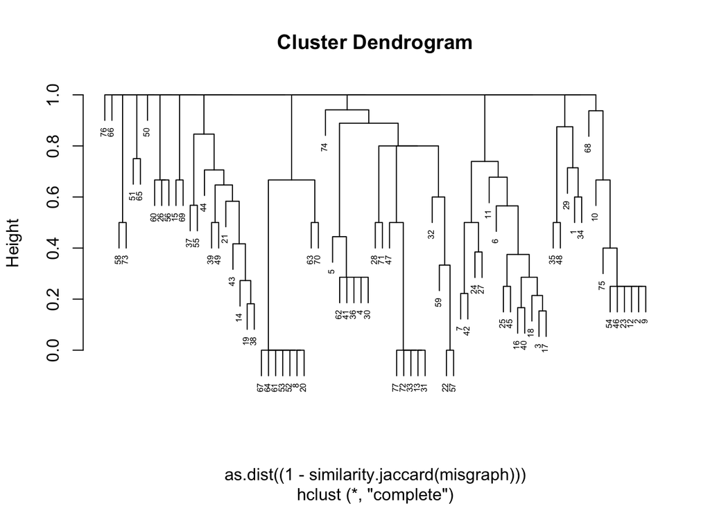

```r
mishclust <- hclust(as.dist((1-similarity.jaccard(misgraph))))
plot(mishclust, cex=0.5)
```

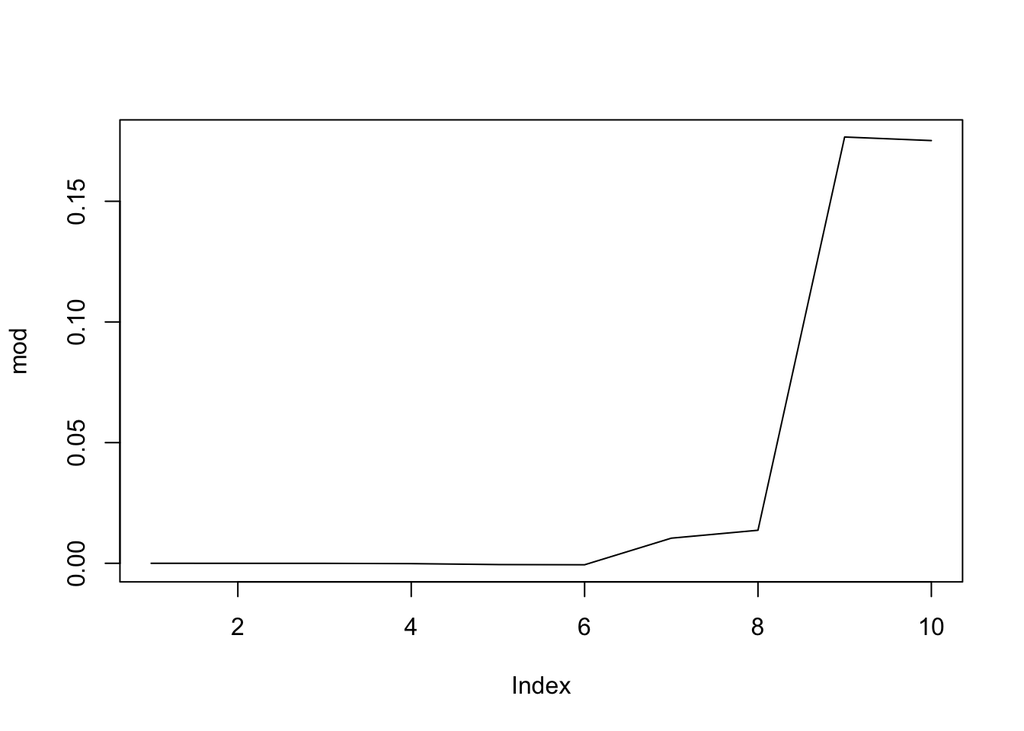

```r
mod = c()
for (i in 1:10){
  labels = cutree(mishclust , i)
  mod[i] = modularity(x=misgraph, membership=labels)
}
plot(mod,type="l")
```

The modularity is a way to measure the connectivity inside the clusters, and so how relevant they are. The graph stops at 10 clusters, but when we increase the index, we notice that it keeps decreasing. It means that 9 is the optimal number of clusters for the agglomerative clustering algorithm, regarding the modularity metric.

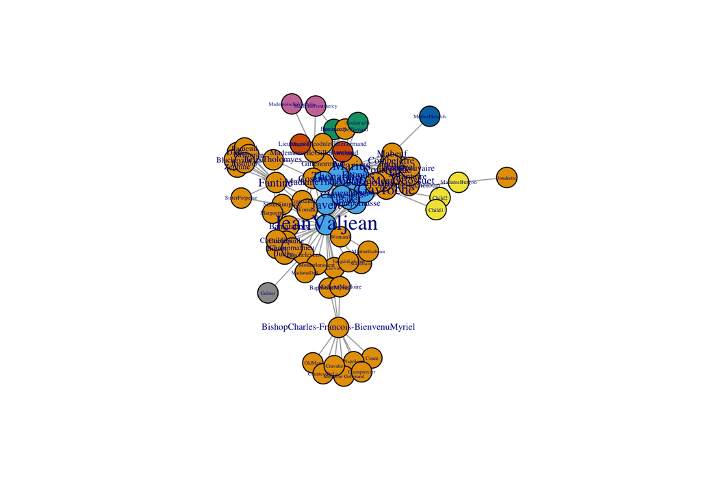

```r
optimal_number_cluster <- 9
labels = cutree(mishclust , optimal_number_cluster)
V(misgraph)$color = labels
plot(misgraph)
```

```r
for (i in 1:9) {
  print(i);
  for (j in 1:77) {
    if (labels[j] == i) {
      print( V(misgraph)$name[j]);
    }
  }
}
```

```
## [1] 1
## [1] "Gillenormand"
## [1] "Zephine"
## [1] "Joly"
## [1] "Brevet"
## [1] "Bamatabois"
## [1] "Gavroche"
## [1] "MadameHucheloup"
## [1] "Count"
## [1] "Dahlia"
## [1] "Fantine"
## [1] "Marius"
## [1] "Blacheville"
## [1] "Scaufflaire"
## [1] "Combeferre"
```

[output cut: 71 more lines]

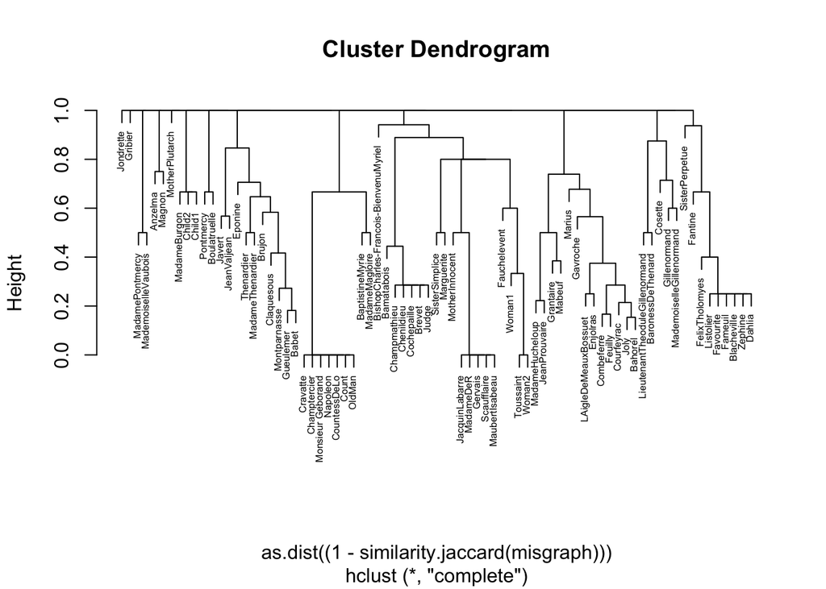

```r
# mishclust$labels <- V(misgraph)$
plot(mishclust, labels = V(misgraph)$name, cex=0.5, hang=0.05)
```

### Edge betweenness

1. The edge betweenness of a node e is caracterized by the betweenness centrality: the sum of the fraction of all-pairs shortest paths that pass through e. The algorithm based in this measure is the following:
- Calculate betwenness scores for all edges in the network
- Find the edge with the highest score and remove it from the network -> If the edge removal splits the graph, then divide the graph into subgroups and compute the edge betweeness of the subgraphs -> Else update the edge betweeness for the whole graph
- Repeat the previous step

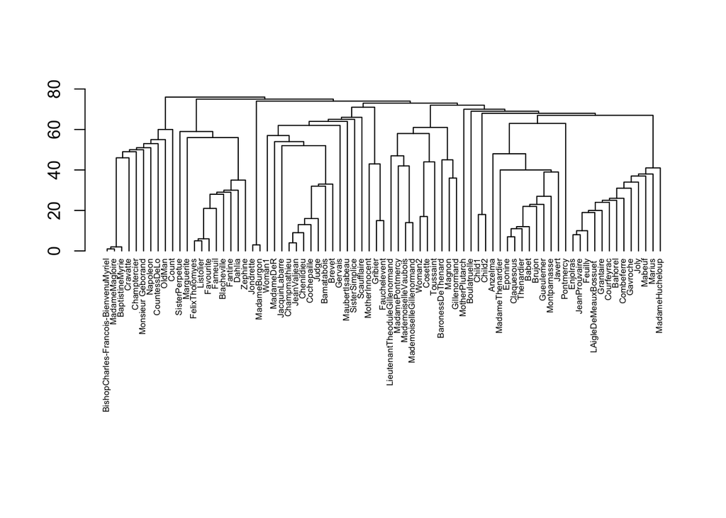

```r
mis_edgeb <- cluster_edge_betweenness(misgraph)
plot_dendrogram(mis_edgeb, cex=0.5, rect=0)
```

(c)

```r
f <- function(i){
  mis_graph2 = delete.edges(misgraph, mis_edgeb$removed.edges[seq(length=i)])
  cl = clusters(mis_graph2)$membership
  modularity(misgraph,cl)
}
mods = sapply(0:ecount(misgraph), f)
mis_graph2<-delete.edges(misgraph, mis_edgeb$removed.edges[seq(length=which.max(mods)-1)])
```

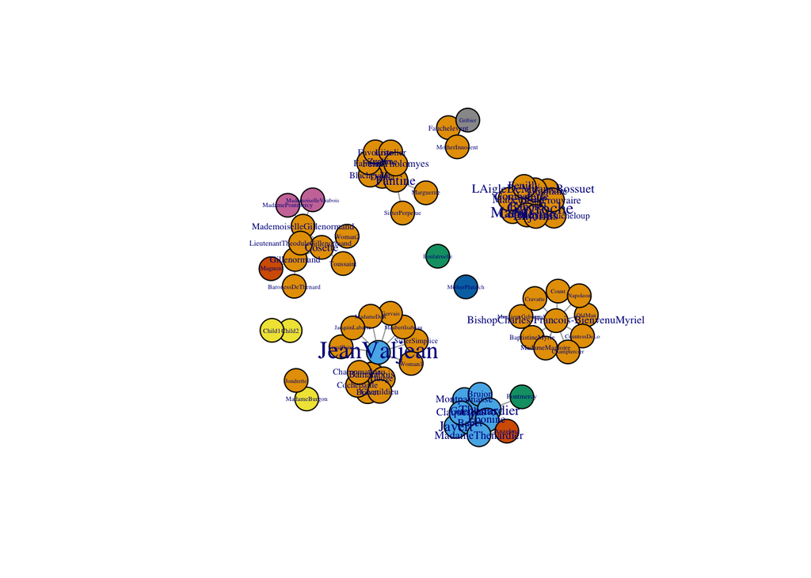

```r
plot(mis_graph2)
```

Now we can observe clear clusters with no link between them.

### Spectral clustering and the Louvain algorithm

```r
set.seed(3)
louvain <- cluster_louvain(misgraph)
length(louvain)
```

```
## [1] 6
```

```r
leading_eigen <- cluster_leading_eigen(misgraph)
length(leading_eigen)
```

```
## [1] 8
```

The Louvain algorithm finds 6 communities, and the spectral algorithm 8.

### Conclusion

```r
modularity(x=misgraph, membership=cutree(mishclust , 9))
```

```
## [1] 0.1766461
```

```r
modularity(mis_edgeb)
```

```
## [1] 0.5380681
```

```r
modularity(louvain)
```

```
## [1] 0.5527234
```

```r
modularity(leading_eigen)
```

```
## [1] 0.5322711
```

The modularities are pretty similar except for the Hierarchical agglomerative clustering method which is significantly lower.